# cancer detection

## Introduction

using human cell records,our aim is to classify cells to whether the samples are benign (mild state) or malignant (evil state). our goal is to determine the cell characteristics by which we can identifiy malignant cells by using a software for predicition instead of taking a sample from the tumer

### Dataset Description

```python
import pandas as pd
```

```python
cell_df=pd.read_csv(r'C:\program alaa\excel 001\cell_samples.csv')
cell_df.head()
```

|  | ID | Clump | UnifSize | UnifShape | MargAdh | SingEpiSize | BareNuc | BlandChrom | NormNucl | Mit | Class |
| --- | --- | --- | --- | --- | --- | --- | --- | --- | --- | --- | --- |
| 0 | 1000025 | 5 | 1 | 1 | 1 | 2 | 1 | 3 | 1 | 1 | 2 |
| 1 | 1002945 | 5 | 4 | 4 | 5 | 7 | 10 | 3 | 2 | 1 | 2 |
| 2 | 1015425 | 3 | 1 | 1 | 1 | 2 | 2 | 3 | 1 | 1 | 2 |
| 3 | 1016277 | 6 | 8 | 8 | 1 | 3 | 4 | 3 | 7 | 1 | 2 |
| 4 | 1017023 | 4 | 1 | 1 | 3 | 2 | 1 | 3 | 1 | 1 | 2 |

```python
cell_df.shape
```

```
(699, 11)
```

```python
cell_df.dtypes
```

```
ID              int64
Clump           int64
UnifSize        int64
UnifShape       int64
MargAdh         int64
SingEpiSize     int64
BareNuc        object
BlandChrom      int64
NormNucl        int64
Mit             int64
Class           int64
dtype: object
```

```python
cell_df['BareNuc'].value_counts()
```

```
1     402
10    132
5      30
2      30
3      28
8      21
4      19
?      16
9       9
7       8
6       4
Name: BareNuc, dtype: int64
```

```python
cell_df=cell_df[pd.to_numeric(cell_df['BareNuc'], errors='coerce').notnull()]
cell_df['BareNuc']=cell_df['BareNuc'].astype('int')
```

```python
cell_df.dtypes
```

```
ID             int64
Clump          int64
UnifSize       int64
UnifShape      int64
MargAdh        int64
SingEpiSize    int64
BareNuc        int32
BlandChrom     int64
NormNucl       int64
Mit            int64
Class          int64
dtype: object
```

the column of interset is 'class' where the value 2 is for the benign cells while the value 4 is for the malignant cells

```python
#distribution of classes
```

```python
malignant_df=cell_df[cell_df['Class']==4][0:200]#take subset of data to allow visualizing the relations
benign_df=cell_df[cell_df['Class']==2][0:200]
```

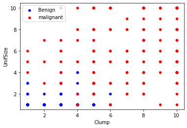

```python
axes=benign_df.plot(kind='scatter', x='Clump',y='UnifSize',color='blue',label='Benign')
malignant_df.plot(kind='scatter', x='Clump',y='UnifSize',color='red',label='malignant',ax=axes)
```

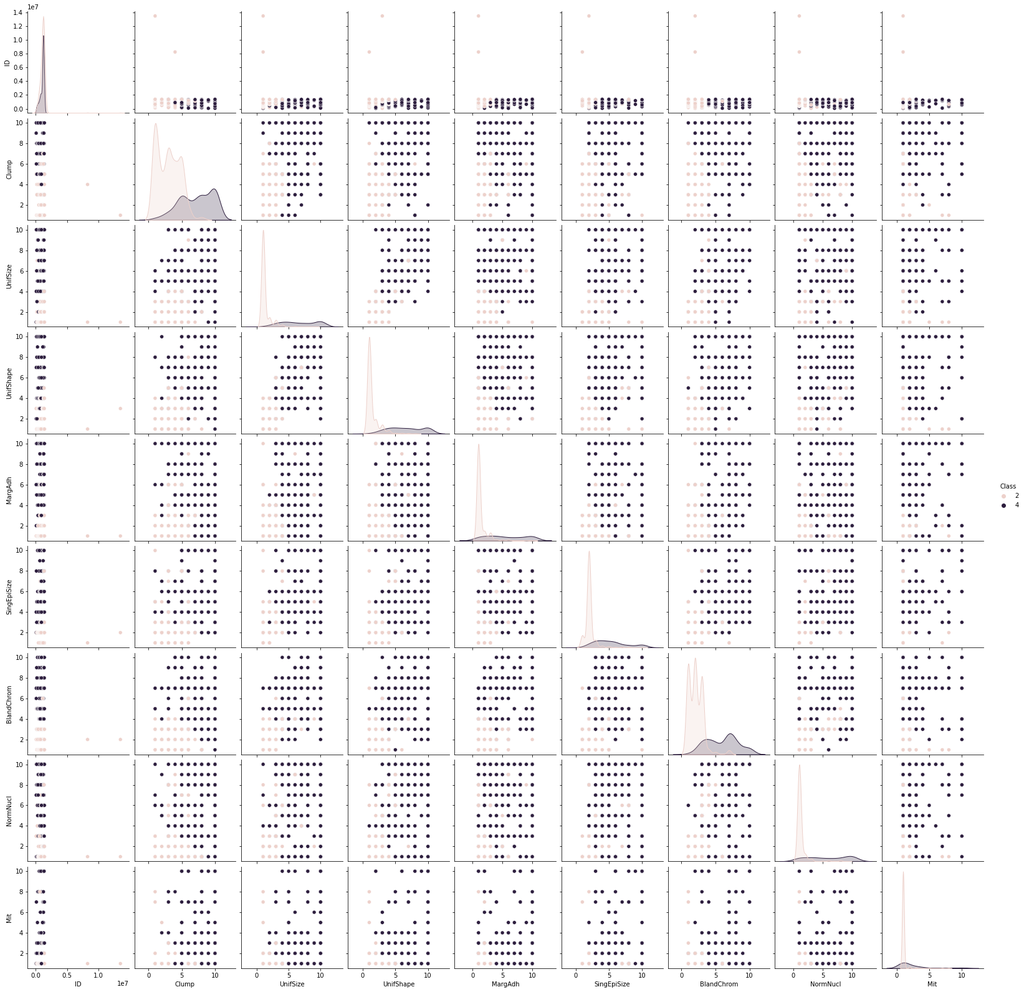

```python
import seaborn as sns
sns.pairplot(cell_df,hue='Class')
```

selecting the columns upon which we can predict the class

```python
cell_df.columns
```

```
Index(['ID', 'Clump', 'UnifSize', 'UnifShape', 'MargAdh', 'SingEpiSize',
       'BareNuc', 'BlandChrom', 'NormNucl', 'Mit', 'Class'],
      dtype='object')
```

```python
feature_df=cell_df[['Clump', 'UnifSize', 'UnifShape', 'MargAdh', 'SingEpiSize',
       'BareNuc', 'BlandChrom', 'NormNucl', 'Mit']]
```

```python
#covert it to numpy array to pass it to the classification function
x=np.asarray(feature_df)#independent var
```

```python
y=np.asarray(cell_df['Class'])#dependent var
```

```python
x[0:5]#value for each column at each row(5 rows)
```

```
array([[ 5,  1,  1,  1,  2,  1,  3,  1,  1],
       [ 5,  4,  4,  5,  7, 10,  3,  2,  1],
       [ 3,  1,  1,  1,  2,  2,  3,  1,  1],
       [ 6,  8,  8,  1,  3,  4,  3,  7,  1],
       [ 4,  1,  1,  3,  2,  1,  3,  1,  1]], dtype=int64)
```

```python
y[0:5] #value of class at each row(5 rows)
```

```
array([2, 2, 2, 2, 2], dtype=int64)
```

dividing the data into train\test datasets

```python
from sklearn.model_selection import train_test_split
x_train, x_test ,y_train, y_test=train_test_split(x,y,test_size=0.2,random_state=4)
#test_size gives the ratio upon which the dataset is divided into tarin and test ex: 0.2 means 20 for test 80 for train
#out of 100 rows
#random state determinte which set of rows are chosen randomly to contribute to each dataset (train,test)
```

```python
x_train.shape
```

```
(546, 9)
```

```python
x_test.shape
```

```
(137, 9)
```

```python
y_train.shape
```

```
(546,)
```

```python
y_test.shape
```

```
(137,)
```

modeling

SVM works by mapping data to a high-dimensional feature space so that data points can be categorized, even when the data are not otherwise linearly separable (This gets done by kernel function of SVM classifier). A separator between the categories is found, then the data is transformed in such a way that the separator could be drawn as a hyperplane.

```python
from sklearn import svm
classifier=svm.SVC(kernel = 'linear', gamma='auto',C=2)
# svc:support vector classifer :the max of the summation of the distances from the hyperplane that crossponds to the nearest
# points to hyperplane
#kernel deterimine the mapping to higher dimensional spaces
#gamma:kernel coffient
#c : cost of error
```

```python
classifier.fit(x_train,y_train)
```

```
SVC(C=2, gamma='auto', kernel='linear')
```

```python
from sklearn.linear_model import LogisticRegression
classifier1 = LogisticRegression()
classifier1.fit(x_train,y_train)
```

```
LogisticRegression()
```

```python
y_predict=classifier.predict(x_test)
```

```python
y_predict1=classifier1.predict(x_test)
```

evaluting the results

```python
from sklearn.metrics import classification_report
print(classification_report(y_test,y_predict))
```

```
              precision    recall  f1-score   support

           2       1.00      0.94      0.97        90
           4       0.90      1.00      0.95        47

    accuracy                           0.96       137
   macro avg       0.95      0.97      0.96       137
weighted avg       0.97      0.96      0.96       137
```

```python
print(classification_report(y_test,y_predict1))
```

```
              precision    recall  f1-score   support

           2       1.00      0.96      0.98        90
           4       0.92      1.00      0.96        47

    accuracy                           0.97       137
   macro avg       0.96      0.98      0.97       137
weighted avg       0.97      0.97      0.97       137
```

```python
from sklearn.metrics import accuracy_score
accuracy=accuracy_score(y_test,y_predict)
```

```python
accuracy
```

```
0.9635036496350365
```

```python
accuracy1=accuracy_score(y_test,y_predict1)
```

```python
accuracy1
```

```
0.9708029197080292
```

```python
from sklearn.model_selection import GridSearchCV
#parameters=[{'c':[1,10,100,1000],'kernel':['linear']},
          # {'c':[1,10,100,1000],'kernel':['rbf'], 'gamma':[0.1,0.2,0.3,0.4,0.5,0.6,0.7,0.8,0.9]}]
parameters=[{'C':[1,10,100],'kernel':['rbf'], 'gamma':[0.1,0.2,0.3,0.4,0.5,0.6,0.7,0.8,0.9]},
            {'C':[0.1,1,100],'kernel':['poly','sigmoid'],'gamma':[1,0.1,0.01,0.001]}]
grid_search=GridSearchCV(estimator=classifier,
                        param_grid=parameters,
                        scoring='accuracy',
                        cv=10,
                        n_jobs=-1)
grid_fit=grid_search.fit(x_train,y_train)
```

```python
best_model=grid_search.best_estimator_
```

```python
best_predictions = best_model.predict(x_test)
```

```python
print(classification_report(y_test,best_predictions))
```

```
              precision    recall  f1-score   support

           2       1.00      0.96      0.98        90
           4       0.92      1.00      0.96        47

    accuracy                           0.97       137
   macro avg       0.96      0.98      0.97       137
weighted avg       0.97      0.97      0.97       137
```

using nonlinear models

```python
from sklearn.ensemble import RandomForestClassifier
forest=RandomForestClassifier(random_state=0)
#Train the supervised model on the training set using .fit(X_train, y_train)
model = forest.fit(x_train, y_train)
prediction_non_linear = model.predict(x_test)
print(classification_report(y_test,prediction_non_linear))
```

```
              precision    recall  f1-score   support

           2       1.00      0.96      0.98        90
           4       0.92      1.00      0.96        47

    accuracy                           0.97       137
   macro avg       0.96      0.98      0.97       137
weighted avg       0.97      0.97      0.97       137
```

```python
cell_df.head()
```

|  | ID | Clump | UnifSize | UnifShape | MargAdh | SingEpiSize | BareNuc | BlandChrom | NormNucl | Mit | Class |
| --- | --- | --- | --- | --- | --- | --- | --- | --- | --- | --- | --- |
| 0 | 1000025 | 5 | 1 | 1 | 1 | 2 | 1 | 3 | 1 | 1 | 2 |
| 1 | 1002945 | 5 | 4 | 4 | 5 | 7 | 10 | 3 | 2 | 1 | 2 |
| 2 | 1015425 | 3 | 1 | 1 | 1 | 2 | 2 | 3 | 1 | 1 | 2 |
| 3 | 1016277 | 6 | 8 | 8 | 1 | 3 | 4 | 3 | 7 | 1 | 2 |
| 4 | 1017023 | 4 | 1 | 1 | 3 | 2 | 1 | 3 | 1 | 1 | 2 |

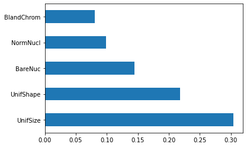

```python
# Extract the feature importances using .feature_importances_
importances = forest.feature_importances_
data=cell_df.drop(['Class','ID'],axis=1)
# Plot

feat_importances = pd.Series(model.feature_importances_, index=data.columns)
feat_importances.nlargest(5).plot(kind='barh')
```

we will try buliding the model using these parameters only and see whether the results are better

```python
features_important=pd.DataFrame(data=cell_df[['UnifSize','UnifShape','BareNuc','NormNucl','BlandChrom']])
y_data=pd.DataFrame(data=cell_df['Class'])
```

```python
# Import functionality for cloning a model

x_train_i, x_test_i ,y_train_i, y_test_i=train_test_split(features_important,y_data,test_size=0.2,random_state=4)
# Reduce the feature space
#X_train_reduced = x_train_i[x_train_i.columns.values[(np.argsort(importances)[::-1])[:5]]]
#X_test_reduced = x_test_i[x_test_i.columns.values[(np.argsort(importances)[::-1])[:5]]]

# Train on the "best" model found from grid search earlier
clf = forest.fit(x_train_i, y_train_i)

# Make new predictions
reduced_predictions = clf.predict(x_test_i)
```

```python
print(classification_report(y_test,reduced_predictions))
```

```
              precision    recall  f1-score   support

           2       1.00      0.96      0.98        90
           4       0.92      1.00      0.96        47

    accuracy                           0.97       137
   macro avg       0.96      0.98      0.97       137
weighted avg       0.97      0.97      0.97       137
```

the results were not improved but the computational cost is less